# Disaster Relief Project: Template

Lauren Horde

Mar 24, 2022

**SYS 6018 | Spring 2022 | University of Virginia**

# 1 Introduction

The goal of this project is to evaluate the performance of 4 supervised learning models to determine which is most adept to assist in humanitarian aid efforts following an environmental crisis in Haiti. Due to the destruction caused by a 7.0 magnitude earthquake in Haiti, an unknown number of residents were displaced and left without communications, shelter, food, and water. It was noted that displaced persons were building temporary shelters using blue tarps. The successful identification of blue tarps could be used to locate these displaced persons. Given the crunch for time in this disaster, a modeling approach can be taken to cut down on the time spent visually inspecting geo-spatial imagery for blue tarps. The model charged with this task must be equipped to find the maximum number of displaced persons, so the following models have been created using 10-fold cross-validation and assessed using several performance measures to correctly identify blue tarp locations.

# 2 Training Data

```r
# Load Required Packages
library(tidyverse)
library(readr)
library(broom)
library(glmnet)
library(yardstick)
library(FNN)
library(caret)
library(tidymodels)
library(pROC)

#load data
x <- read_csv("HaitiTraining.csv")
summary(x)
```

```
#>     Class                Red          Green            Blue
#>  Length:63241       Min.   : 48   Min.   : 48.0   Min.   : 44.0
#>  Class :character   1st Qu.: 80   1st Qu.: 78.0   1st Qu.: 63.0
#>  Mode  :character   Median :163   Median :148.0   Median :123.0
#>                     Mean   :163   Mean   :153.7   Mean   :125.1
#>                     3rd Qu.:255   3rd Qu.:226.0   3rd Qu.:181.0
#>                     Max.   :255   Max.   :255.0   Max.   :255.0
```

```r
#change class to factor, isolate blue tarp hits and misses
x$Class <- as.factor(x$Class)

x$BlueTarp <- ifelse(x$Class=="Blue Tarp", "Hit", "Miss")
x$BlueTarp <- as.factor(x$BlueTarp)
```

## 2.1 Exploratory Data Analysis

### 2.1.1 Classification Breakdown

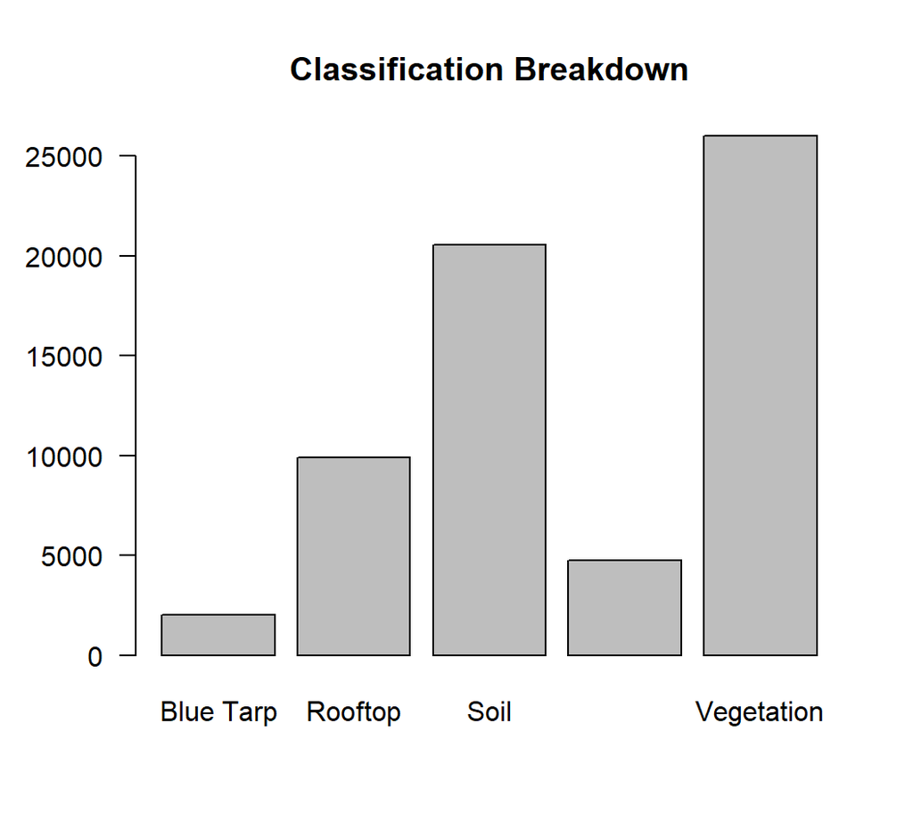

```r
plot(x$Class, main="Classification Breakdown", las=1)
```

```r
table(x$Class, x$BlueTarp)
```

```
#>
#>                      Hit  Miss
#>   Blue Tarp         2022     0
#>   Rooftop              0  9903
#>   Soil                 0 20566
#>   Various Non-Tarp     0  4744
#>   Vegetation           0 26006
```

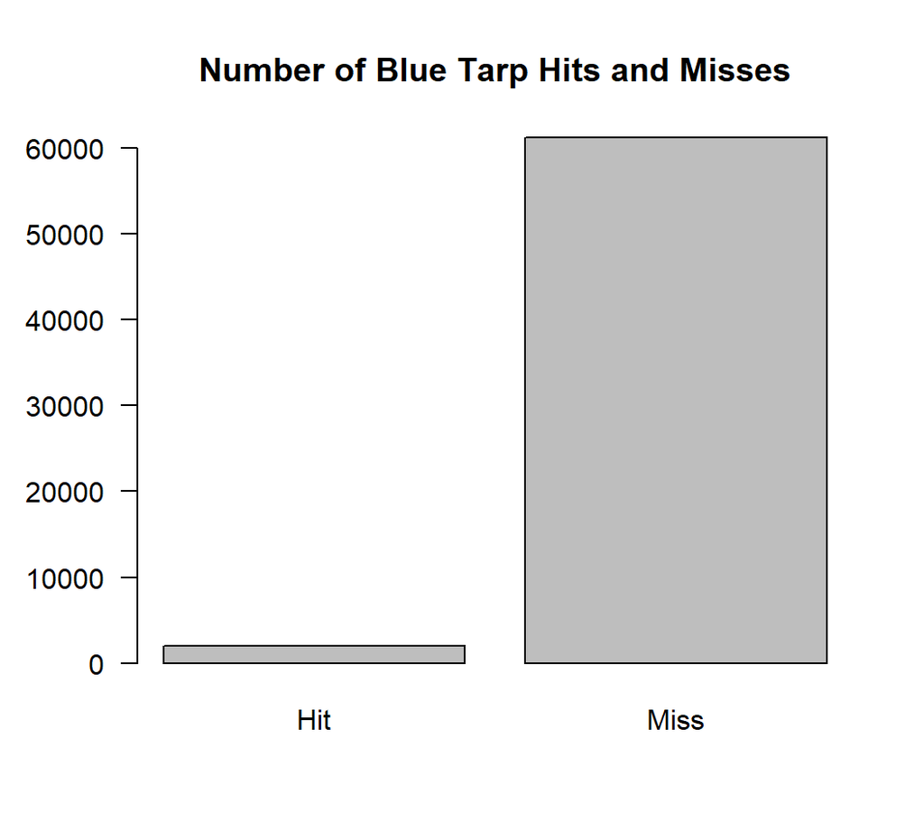

```r
plot(x$BlueTarp, main="Number of Blue Tarp Hits and Misses", las=1)
```

```r
table(x$BlueTarp)
```

```
#>
#>   Hit  Miss
#>  2022 61219
```

### 2.1.2 Red Values

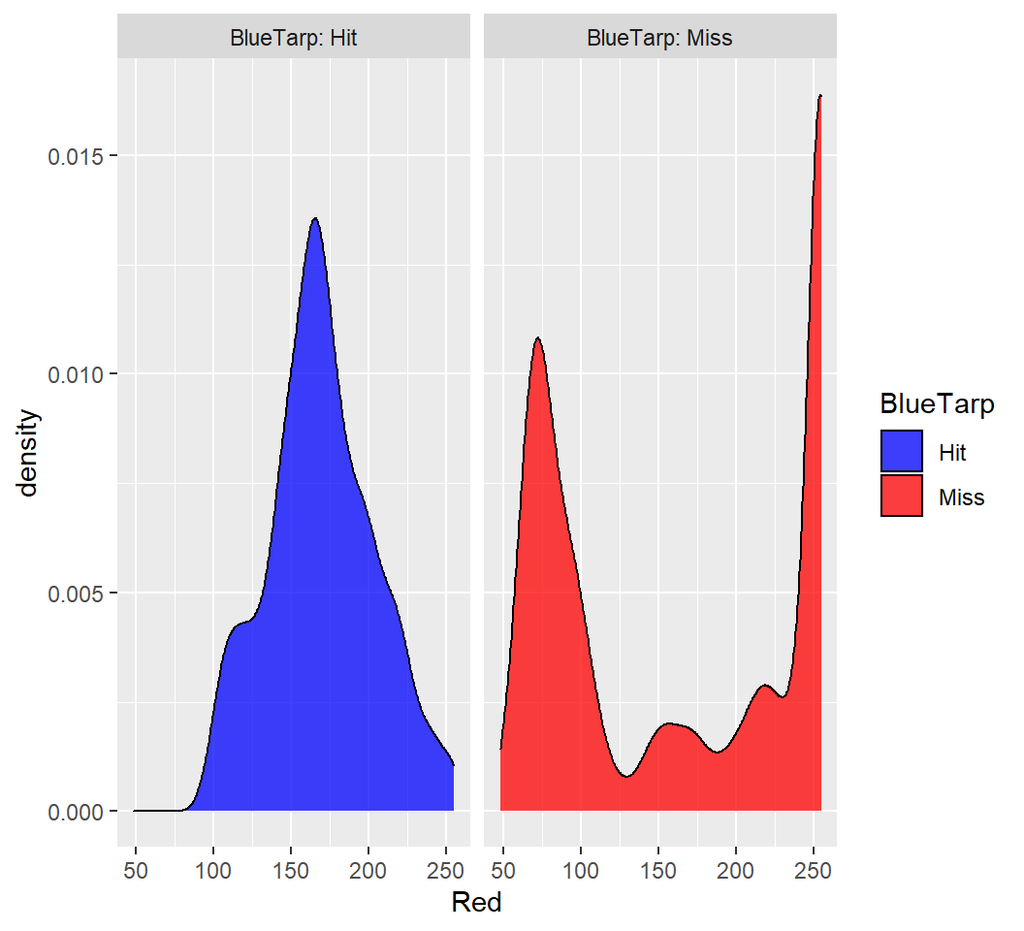

```r
plot_cols = c("Hit"="blue", "Miss"="red")
red.value <- ggplot(x, aes(Red, fill=BlueTarp)) +
  geom_density(alpha=.75) +
  facet_wrap(~BlueTarp, labeller=label_both) +
  scale_fill_manual(values=plot_cols)
red.value
```

### 2.1.3 Green Values

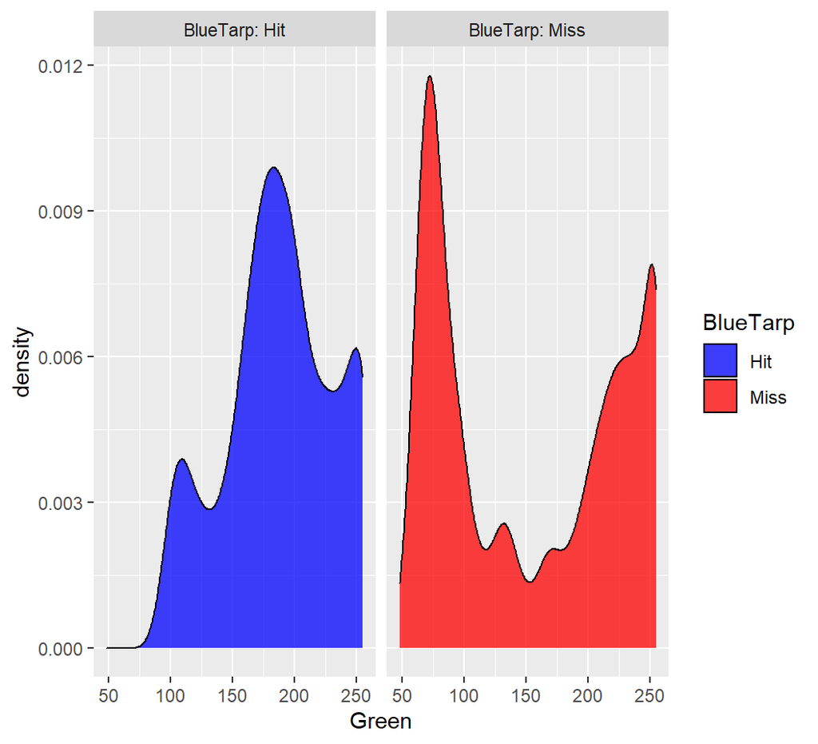

```r
plot_cols = c("Hit"="blue", "Miss"="red")
green.value <- ggplot(x, aes(Green, fill=BlueTarp)) +
  geom_density(alpha=.75) +
  facet_wrap(~BlueTarp, labeller=label_both) +
  scale_fill_manual(values=plot_cols)
green.value
```

### 2.1.4 Blue Values

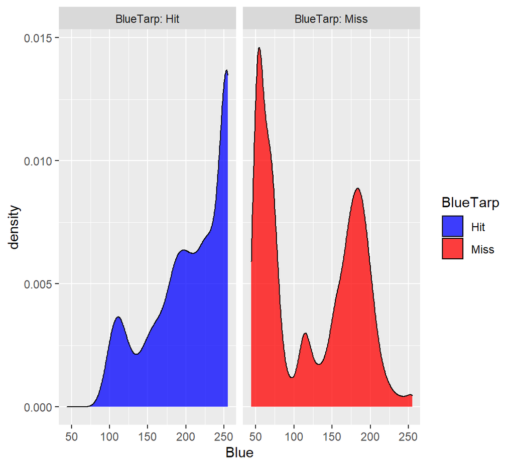

```r
plot_cols = c("Hit"="blue", "Miss"="red")
blue.value <- ggplot(x, aes(Blue, fill=BlueTarp)) +
  geom_density(alpha=.75) +
  facet_wrap(~BlueTarp, labeller=label_both) +
  scale_fill_manual(values=plot_cols)
blue.value
```

# {-}

# 3 Model Training

```r
sample.size <- floor(0.60*nrow(x))
set.seed(2022)
train.data <- sample(seq_len(nrow(x)), size=sample.size)

train <- x[train.data,]
test <- x[-train.data,]
```

## 3.1 Set-up

Training controls apply to the CARET package for building models. By using method=“cv”, this function implements cross-validation at a manually set number (number=10).

```r
train.control <- trainControl(method="cv",
                              number=10,
                              savePredictions=TRUE,
                              classProbs = TRUE)
```

## 3.2 Logistic Regression

### 3.2.1 Model Setup

```r
set.seed(2023)
haiti.log <- train(BlueTarp ~ Red + Green + Blue,
                   data=train, method ="glm",
                   family="binomial",
                   trControl=train.control)

log.test.pred <- predict(haiti.log, newdata=test)
haiti.prob <- predict(haiti.log, newdata=test, type="prob")[,"Hit"]
```

### 3.2.2 Threshold Selection

The threshold 0.25 was chosen based on the highest accuracy when testing threshold increments of 0.05 between 0 and 1.

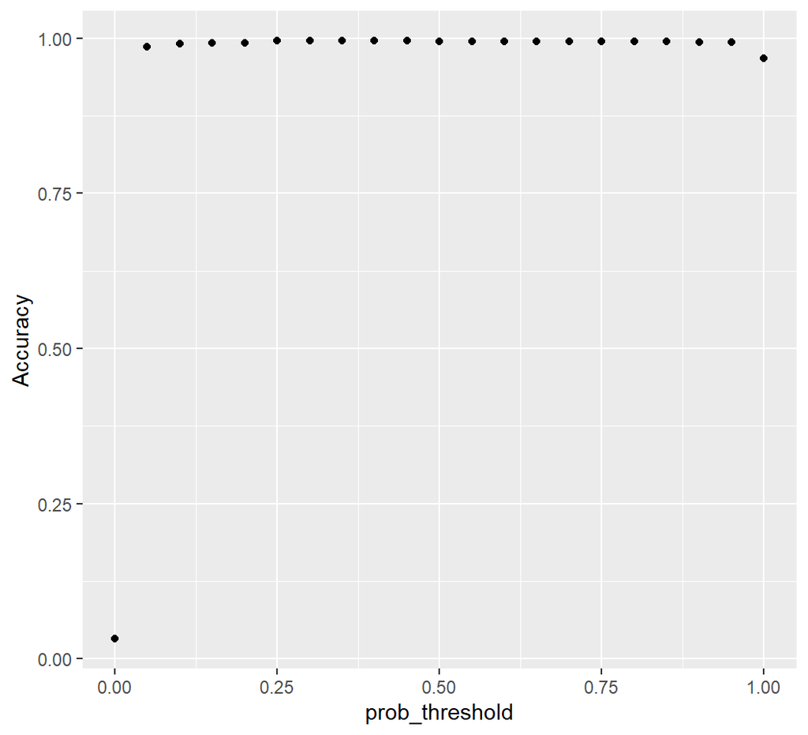

```r
log.threshold <- thresholder(haiti.log,
                             threshold = seq(0, 1, by = 0.05),
                             final = TRUE)

log.threshold.plot <- ggplot(log.threshold, aes(x=prob_threshold, y = Accuracy)) +
  geom_point()
log.threshold.plot
```

```r
log.pred.thres = as.factor(ifelse(predict(haiti.log,
                                          newdata=test,
                                          type="prob")$Hit>0.25, "Hit", "Miss"))
```

## 3.3 KNN

### 3.3.1 Model Setup

```r
set.seed(2024)
haiti.knn <- train(BlueTarp ~ Red + Green + Blue, data=train, method ="knn",
                 trControl=train.control,
                 preProcess = c("center", "scale"),
                 tuneLength = 10)

knn.test.pred <- predict(haiti.knn, newdata=test)
knn.prob <- predict(haiti.knn, newdata=test, type="prob")[,"Hit"]
```

### 3.3.2 Tuning Parameter $k$

```r
haiti.knn$bestTune
```

```
#>    k
#> 4 11
```

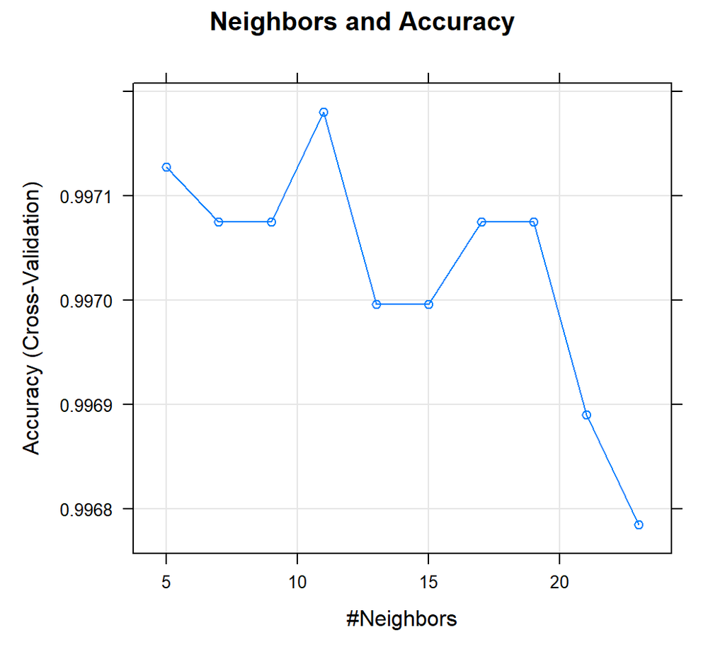

```r
neighbors <- plot(haiti.knn, main="Neighbors and Accuracy")
neighbors
```

### 3.3.3 Threshold Selection

The threshold 0.5 was chosen based on the highest accuracy when testing threshold increments of 0.05 between 0 and 1. This result is the same as the default threshold implemented by the CARET model.

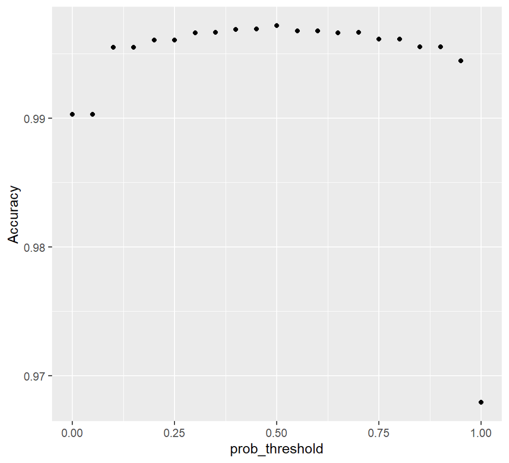

```r
knn.threshold <- thresholder(haiti.knn,
                             threshold = seq(0, 1, by = 0.05),
                             final = TRUE)

knn.threshold.plot <- ggplot(knn.threshold, aes(x=prob_threshold, y = Accuracy)) +
  geom_point()
knn.threshold.plot
```

```r
knn.pred.thres = as.factor(ifelse(predict(haiti.knn,
                                    newdata=test,
                                    type="prob")$Hit>0.5, "Hit", "Miss"))
```

## 3.4 Penalized Logistic Regression (ElasticNet)

### 3.4.1 Model Setup

```r
set.seed(2025)

#generate grid of lambda and alpha values
alpha.lambda = expand.grid(alpha=seq(0, 1, length=10),
                           lambda= seq(0, 100, length=100))

#generates 1000 models testing alpha and lambda values (10 x 100)
enet.haiti <- train(BlueTarp ~ Red + Green + Blue,
                    data=train, method ="glmnet",
                    preProcess = c("center", "scale"),
                    trControl=train.control,
                    tuneGrid = alpha.lambda,
                    tuneLength = 10
                    )

enet.test.pred <- predict(enet.haiti, newdata=test)
enet.prob <- predict(enet.haiti, newdata=test, type="prob")[,"Hit"]
```

### 3.4.2 Tuning Parameters for Penalized Logistic Regression

Lambda = 0 Alpha = 1

```r
enet.haiti$bestTune$lambda
```

```
#> [1] 0
```

```r
enet.haiti$bestTune$alpha
```

```
#> [1] 1
```

### 3.4.3 Threshold Selection

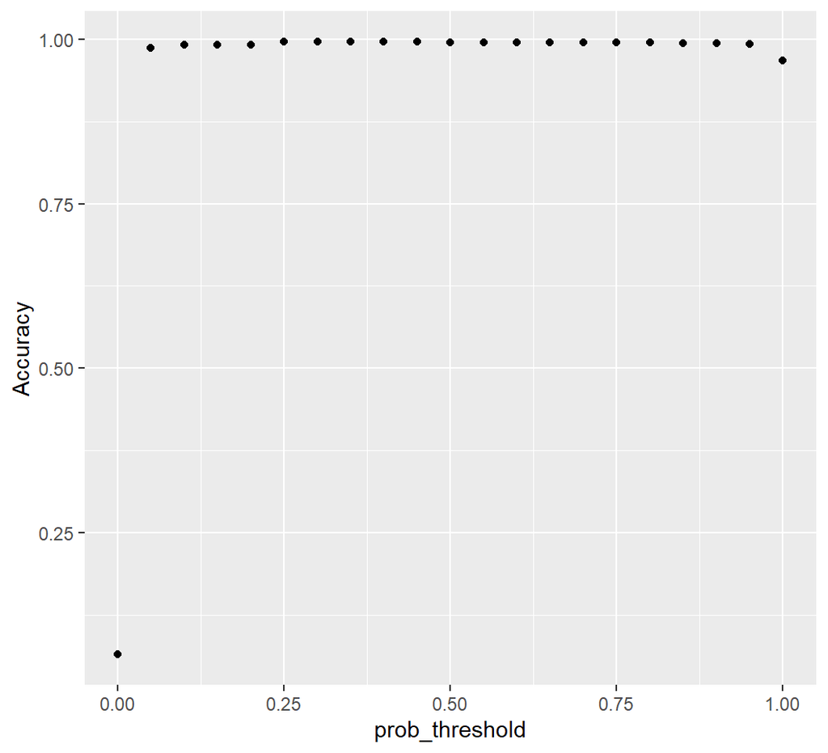

```r
enet.threshold <- thresholder(enet.haiti,
                             threshold = seq(0, 1, by = 0.05),
                             final = TRUE)

enet.threshold.plot <- ggplot(enet.threshold, aes(x=prob_threshold, y=Accuracy)) +
  geom_point()
enet.threshold.plot
```

```r
enet.pred.thres = as.factor(ifelse(predict(enet.haiti,
                                          newdata=test,
                                          type="prob")$Hit>0.05, "Hit", "Miss"))
```

## 3.5 Support Vector Machines (SVM)

### 3.5.1 Model Setup

```r
set.seed(2026)
svm.haiti7 <- train(BlueTarp ~ Red + Green + Blue,
                    data=train, method ="svmLinear",
                    preProcess = c("center", "scale"),
                    trControl=train.control,
                    tuneGrid=data.frame(C = seq(0.1, 1, length=10)))

svm.test.pred <- predict(svm.haiti7, newdata=test)
svm.prob <- predict(svm.haiti7, newdata=test, type="prob")[,"Hit"]
```

### 3.5.2 Tuning Parameters

Ten values of C from 0.1 to 1 were manually set to be tested using the CARET package. If C is not manually set, CARET will apply a default C of 1. The values 0.1 to 1 were chosen to be tested based on prior modeling attempts (see appendix code). Values between 0.1 and 100 were pilot tested, with the best fit being 0.1 and 1. With this result, I decided to test values between 0.1 and 1 to further refine the model.

The optimal C using linear kernel methods was determined to be 0.6 based on the highest accuracy value.

```r
svm.haiti7$bestTune
```

```
#>     C
#> 6 0.6
```

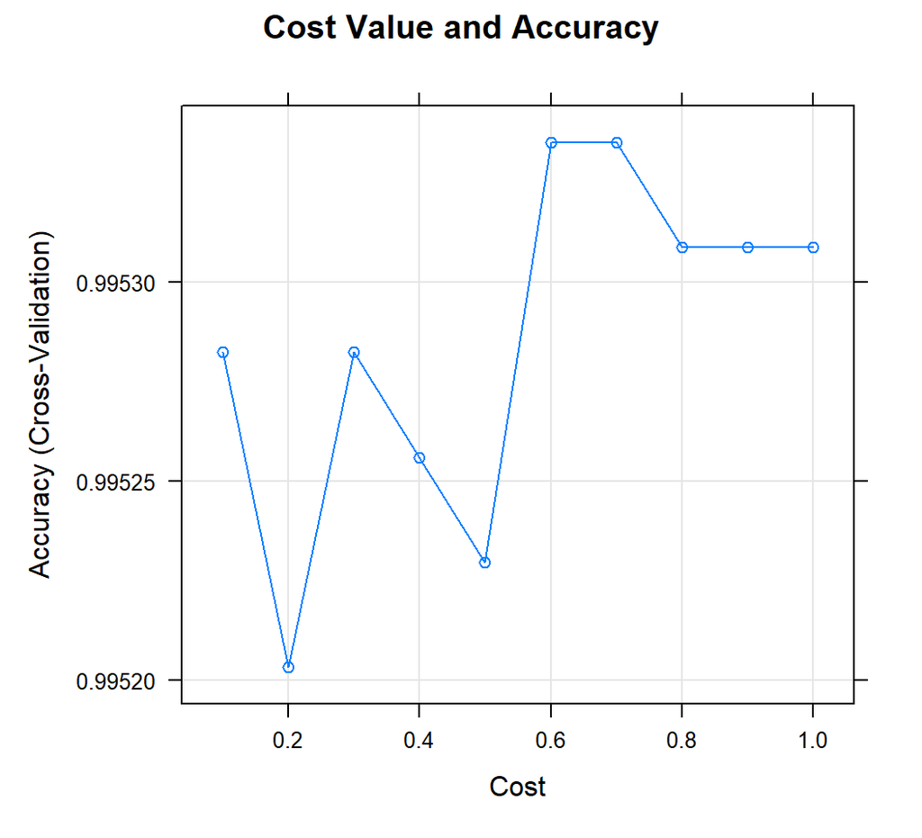

```r
cost.selection <- plot(svm.haiti7, main="Cost Value and Accuracy")
cost.selection
```

### 3.5.3 Threshold Selection

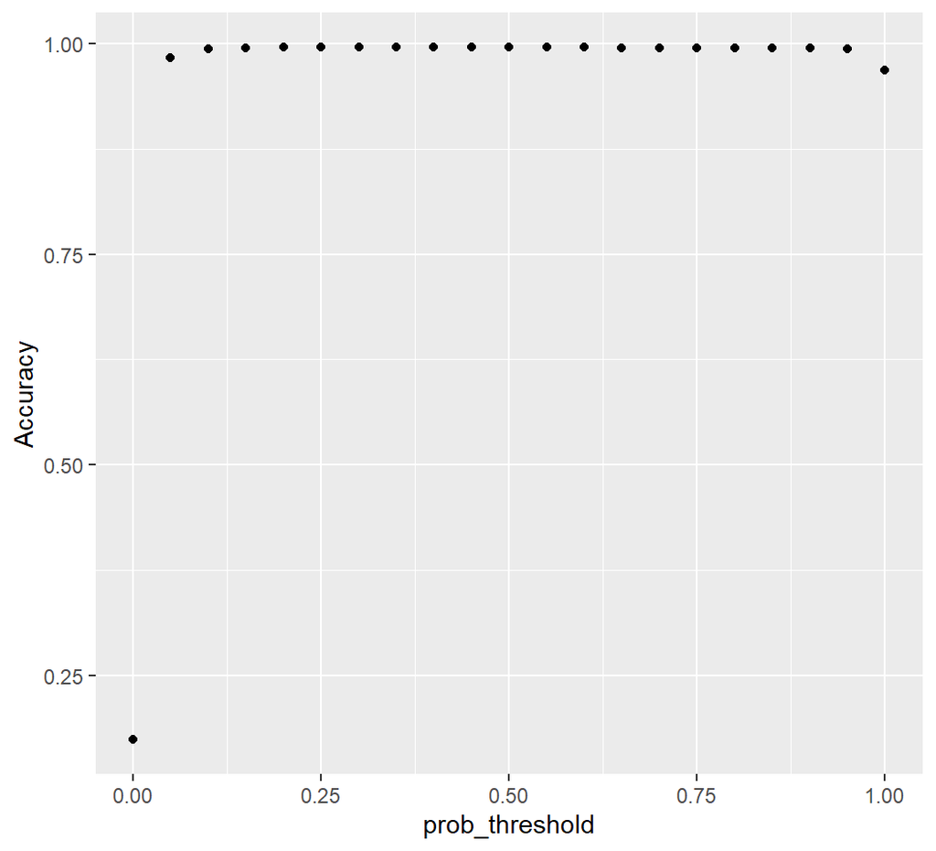

```r
svm.threshold <- thresholder(svm.haiti7,
                              threshold = seq(0, 1, by = 0.05),
                              final = TRUE)

svm.threshold.plot <- ggplot(svm.threshold, aes(x=prob_threshold, y=Accuracy)) +
  geom_point()
svm.threshold.plot
```

```r
svm.pred.thres = as.factor(ifelse(predict(svm.haiti7,
                                           newdata=test,
                                           type="prob")$Hit>0.25, "Hit", "Miss"))
```

# 4 Results (Cross-Validation)

## 4.1 Logistic

```r
log.performance.t <- confusionMatrix(test$BlueTarp, log.pred.thres, positive="Hit")
log.overall.stats.t <- log.performance.t$overall
log.confusion.matrix.t <- log.performance.t$table

log.test.pred.plot <- plot(log.pred.thres, main="Logistic Classification Results")
```

```r
log.test.pred.plot
```

```
#>      [,1]
#> [1,]  0.7
#> [2,]  1.9
```

```r
log.confusion.matrix.t
```

```
#>           Reference
#> Prediction   Hit  Miss
#>       Hit    747    58
#>       Miss    49 24443
```

```r
log.accuracy.t <- log.performance.t$overall[1] #accuracy = 0.9957702
log.tpr.t <- log.performance.t$byClass[1] #TPR aka sensitivity = 0.9384422
log.fpr.t <- log.performance.t$byClass[2] #FPR aka specificity = 0.9976327
log.precision.t <- log.performance.t$byClass[5] #precision = 0.9279503

log.pred.thres1 <- as.numeric(log.pred.thres)
log.roc.t <- roc(test$BlueTarp, log.pred.thres1, ordered=TRUE)
log.auc.t <- auc(log.roc.t) #AUROC=0.963
```

## 4.2 KNN

```r
knn.performance.t <- confusionMatrix(test$BlueTarp, knn.pred.thres, positive="Hit")
knn.overall.stats.t <- knn.performance.t$overall
knn.confusion.matrix.t <- knn.performance.t$table

knn.test.pred.plot <- plot(knn.pred.thres, main="KNN Classification Results")
```

```r
knn.test.pred.plot
```

```
#>      [,1]
#> [1,]  0.7
#> [2,]  1.9
```

```r
knn.confusion.matrix.t
```

```
#>           Reference
#> Prediction   Hit  Miss
#>       Hit    775    30
#>       Miss    43 24449
```

```r
knn.accuracy.t <- knn.performance.t$overall[1] #accuracy = 0.9971143
knn.tpr.t <- knn.performance.t$byClass[1] #TPR aka sensitivity = 0.9474328
knn.fpr.t <- knn.performance.t$byClass[2] #FPR aka specificity = 0.9987745
knn.precision.t <- knn.performance.t$byClass[5] #precision = 0.9627329

knn.pred.thres1 <- as.numeric(knn.pred.thres)
knn.roc.t <- roc(test$BlueTarp, knn.pred.thres1, ordered=TRUE)
knn.auc.t <- auc(knn.roc.t) #AUROC=0.9805
```

## 4.3 Elastic Net

```r
enet.performance.t <- confusionMatrix(test$BlueTarp, enet.pred.thres, positive="Hit")
enet.overall.stats.t <- enet.performance.t$overall
enet.confusion.matrix.t <- enet.performance.t$table

enet.pred.thres = as.factor(ifelse(predict(enet.haiti,
                                          newdata=test,
                                          type="prob")$Hit>0.05, "Hit", "Miss"))
enet.test.pred.plot <- plot(enet.pred.thres, main="Elastic Net Classification Results")
```

```r
enet.test.pred.plot
```

```
#>      [,1]
#> [1,]  0.7
#> [2,]  1.9
```

```r
enet.confusion.matrix.t
```

```
#>           Reference
#> Prediction   Hit  Miss
#>       Hit    788    17
#>       Miss   339 24153
```

```r
enet.accuracy.t <- enet.performance.t$overall[1] #accuracy = 0.9859272
enet.tpr.t <- enet.performance.t$byClass[1] #TPR aka sensitivity = 0.6992014
enet.fpr.t <- enet.performance.t$byClass[2] #FPR aka specificity = 0.9992966
enet.precision.t <- enet.performance.t$byClass[5] #precision = 0.978882

enet.pred.thres1 <- as.numeric(enet.pred.thres)
enet.roc.t <- roc(test$BlueTarp, enet.pred.thres1, ordered=TRUE)
enet.auc.t <- auc(enet.roc.t) #AUROC=0.9825
```

## 4.4 SVM

```r
svm.performance.t <- confusionMatrix(test$BlueTarp, svm.pred.thres, positive="Hit")
svm.overall.stats.t <- svm.performance.t$overall
svm.confusion.matrix.t <- svm.performance.t$table

svm.pred.thres = as.factor(ifelse(predict(svm.haiti7,
                                           newdata=test,
                                           type="prob")$Hit>0.25, "Hit", "Miss"))
svm.test.pred.plot <- plot(svm.pred.thres, main="Linear SVM Classification Results")
```

```r
svm.test.pred.plot
```

```
#>      [,1]
#> [1,]  0.7
#> [2,]  1.9
```

```r
svm.confusion.matrix.t
```

```
#>           Reference
#> Prediction   Hit  Miss
#>       Hit    743    62
#>       Miss    44 24448
```

```r
svm.accuracy.t <- svm.performance.t$overall[1] #accuracy = 0.9958098
svm.tpr.t <- svm.performance.t$byClass[1] #TPR aka sensitivity = 0.9440915
svm.fpr.t <- svm.performance.t$byClass[2] #FPR aka specificity = 0.9974704
svm.precision.t <- svm.performance.t$byClass[5] #precision = 0.9229814

svm.pred.thres1 <- as.numeric(svm.pred.thres)
svm.roc.t <- roc(test$BlueTarp, svm.pred.thres1, ordered=TRUE)
svm.auc.t <- auc(svm.roc.t) #AUROC=0.9606
```

## 4.5 Performance Table

```r
Model <- c("Logistic Regression", "KNN", "Elastic Net", "SVM")
Tuning <- c("N/A", "K=11", "Alpha=1, Lambda=0", "C=0.6")
AUROC <- c(log.auc.t, knn.auc.t, enet.auc.t, svm.auc.t)
Threshold <- c("0.25", "0.5", "0.05", "0.25")
Accuracy <- c(log.accuracy.t, knn.accuracy.t, enet.accuracy.t, svm.accuracy.t)
TPR <- c(log.tpr.t, knn.tpr.t, enet.tpr.t, svm.tpr.t)
FPR <- c(log.fpr.t, knn.fpr.t, enet.fpr.t, svm.fpr.t)
Precision <- c(log.precision.t, knn.precision.t, enet.precision.t, svm.precision.t)

Parameters <- data.frame(Model, Tuning, AUROC, Threshold, Accuracy, TPR, FPR, Precision)
tablefinal <- knitr::kable(Parameters, "pipe", align=c("l", "c", "c", "c", "c", "c", "c", "c"))
tablefinal
```

[output not shown]

## 4.6 ROC Curves

### 4.6.1 Logistic

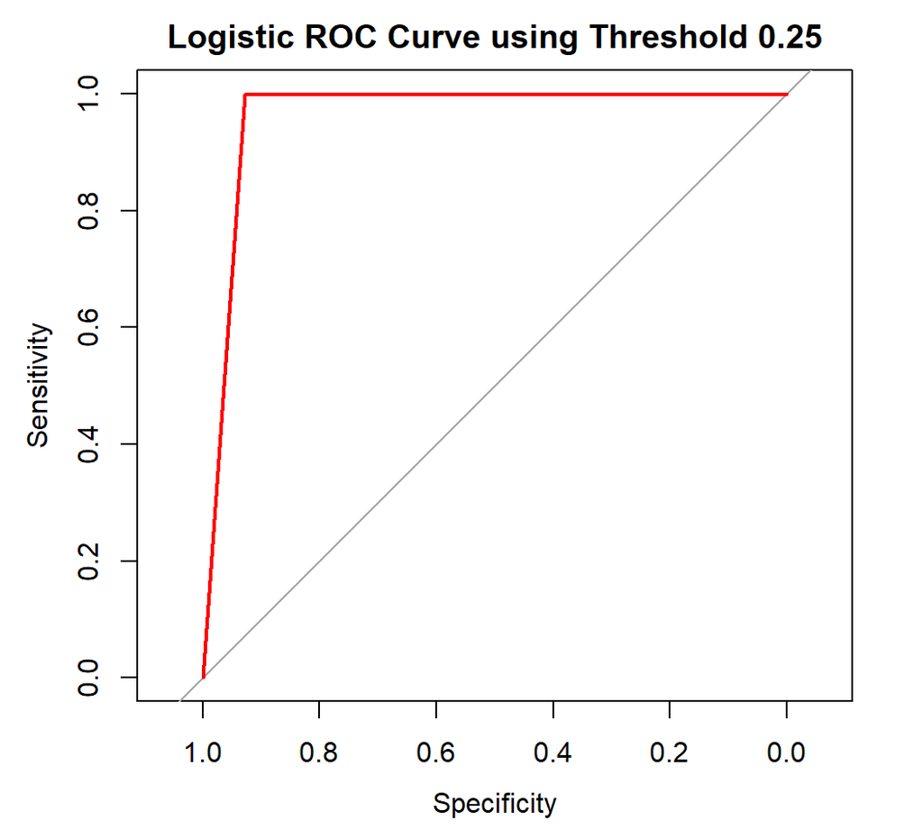

```r
log.roc.plot.t <- plot(log.roc.t, col="red", main="Logistic ROC Curve using Threshold 0.25")
```

### 4.6.2 KNN

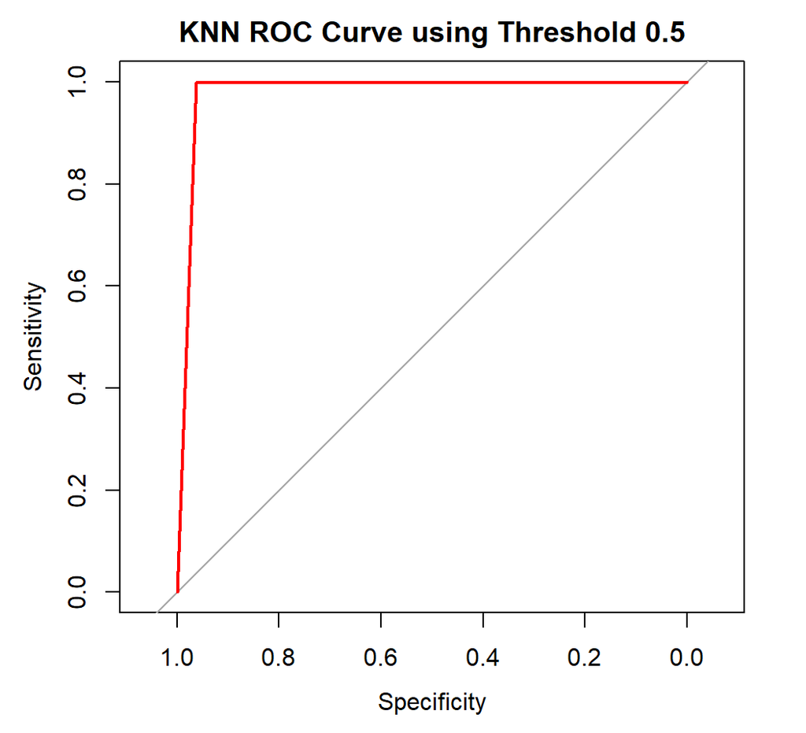

```r
knn.roc.plot.t <- plot(knn.roc.t, col="red", main="KNN ROC Curve using Threshold 0.5")
```

### 4.6.3 Elastic Net

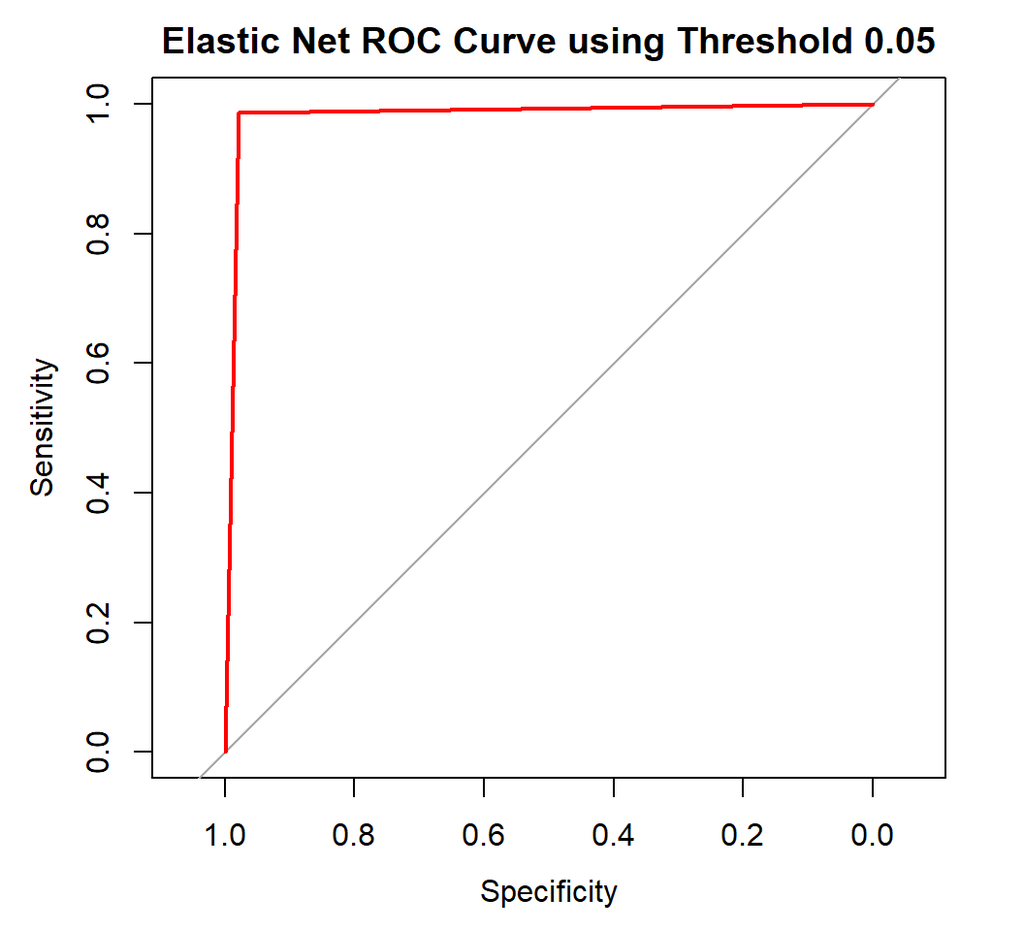

```r
enet.roc.plot.t <- plot(enet.roc.t, col="red", main="Elastic Net ROC Curve using Threshold 0.05")
```

### 4.6.4 SVM

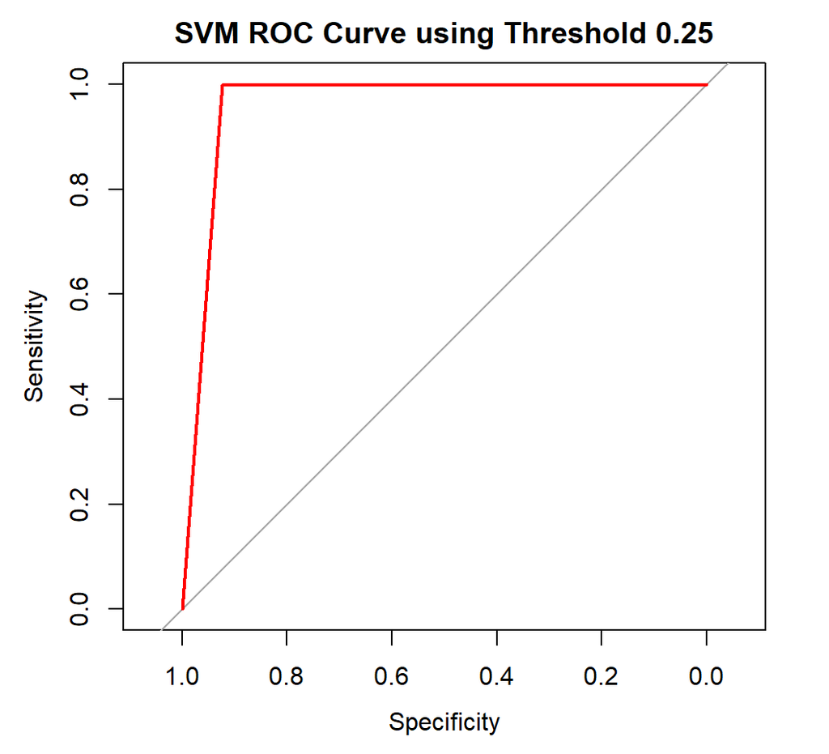

```r
svm.roc.plot.t <- plot(svm.roc.t, col="red", main="SVM ROC Curve using Threshold 0.25")
```

# {-}

# 5 Conclusions

# 6 References

1. https://www.tutorialspoint.com/r/r_factors.htm
2. https://stackoverflow.com/questions/9251326/convert-data-frame-column-format-from-character-to-factor
3. https://www.geeksforgeeks.org/dummy-variables-in-r-programming/
4. https://r4ds.had.co.nz/exploratory-data-analysis.html
5. https://stackoverflow.com/questions/17200114/how-to-split-data-into-training-testing-sets-using-sample-function
6. https://cran.r-project.org/web/packages/caret/caret.pdf
7. https://remiller1450.github.io/s230f19/caret2.html
8. http://rstudio-pubs-static.s3.amazonaws.com/274284_cfbabe09cd2c4e2984cd965daf7cb2c5.html
9. https://blog.revolutionanalytics.com/2016/05/using-caret-to-compare-models.html
10. https://stackoverflow.com/questions/30366143/how-to-compute-roc-and-auc-under-roc-after-training-using-caret-in-r
11. https://topepo.github.io/caret/measuring-performance.html
12. https://rdrr.io/cran/caret/man/recall.html
13. https://dataaspirant.com/knn-implementation-r-using-caret-package/
14. https://daviddalpiaz.github.io/r4sl/the-caret-package.html
15. https://rdrr.io/cran/caret/man/recall.html
16. https://stackoverflow.com/questions/62437321/set-cutoff-threshold-when-predicting-in-r
17. https://daviddalpiaz.github.io/r4sl/elastic-net.html#classification-1
18. http://www.sthda.com/english/articles/37-model-selection-essentials-in-r/153-penalized-regression-essentials-ridge-lasso-elastic-net/
19. https://rpubs.com/uky994/593668
20. https://stackoverflow.com/questions/12809633/parameter-c-in-svm-standard-to-find-best-parameter

# 7 Appendix

```
# Training Data / EDA----------
#Load data, explore data, etc.
library(tidyverse)
library(readr)
library(broom)
library(glmnet)
library(yardstick)
library(FNN)
library(caret)
library(tidymodels)
library(pROC)

#load data
x <- read_csv("HaitiTraining.csv")
summary(x)

#change class to factor, isolate blue tarp hits and misses
x$Class <- as.factor(x$Class)

x$BlueTarp <- ifelse(x$Class=="Blue Tarp", "Hit", "Miss")
x$BlueTarp <- as.factor(x$BlueTarp)

#exploratory data analysis
plot(x$Class, main="Classification Breakdown", las=1)
plot(x$BlueTarp, main="Number of Blue Tarp Hits and Misses", las=1)

table(x$Class, x$BlueTarp)
table(x$BlueTarp)

plot_cols = c("Hit"="blue", "Miss"="red")

red.value <- ggplot(train, aes(Red, fill=BlueTarp)) +
  geom_density(alpha=.75) +
  facet_wrap(~BlueTarp, labeller=label_both) +
  scale_fill_manual(values=plot_cols)

green.value <- ggplot(train, aes(Green, fill=BlueTarp)) +
  geom_density(alpha=.75) +
  facet_wrap(~BlueTarp, labeller=label_both) +
  scale_fill_manual(values=plot_cols)
```

[output cut: 340 more lines]

[output not shown]